# HW-4

2023-04-10

Authors : Mankirat Singh Bhamra MXB220061 - Harikrishna Dev HXD220000 - Krishnan Venkatesan KXV220007 - Medha Priyanga Saravanan MXS220057

Part I: Logistic Regression 1. Estimate a logistic regression model using “buyer” as the dependent variable and the following as predictor variables: * last * total_ * gender * child * youth * cook * do_it * reference * art * geog

Hint: To do this in R, first transform the buyer and gender variables into a 0/1 dummy variable using data.table syntax Then run the logistic regression command. Finally, ask R to create a new variable that contains the predicted probability of purchase for each consumer.

```r
require(data.table)
```

```r
bbb <- fread("~/Library/Mobile Documents/com~apple~CloudDocs/School Work/Sem 2/BUAN 6337/BUAN_6337_Predictive_Analysis/HW/HW-4/BBB.csv",
             na.strings = c("NA", ""),
               sep = "auto",
               stringsAsFactors = FALSE,
               data.table = TRUE,)
summary(bbb)
```

```
##     acctnum         gender             state                zip
##  Min.   :10001   Length:50000       Length:50000       Min.   :  801
##  1st Qu.:22501   Class :character   Class :character   1st Qu.: 7643
##  Median :35000   Mode  :character   Mode  :character   Median :11208
##  Mean   :35000                                         Mean   :11531
##  3rd Qu.:47500                                         3rd Qu.:16242
##  Max.   :60000                                         Max.   :21244
##       zip3           first            last           book_
##  Min.   :  8.0   Min.   : 1.00   Min.   : 1.00   Min.   : 15.00
##  1st Qu.: 76.0   1st Qu.:11.00   1st Qu.: 7.00   1st Qu.: 15.00
##  Median :112.0   Median :21.00   Median :11.00   Median : 28.00
##  Mean   :114.9   Mean   :25.67   Mean   :12.36   Mean   : 46.83
##  3rd Qu.:162.0   3rd Qu.:35.00   3rd Qu.:15.00   3rd Qu.: 71.00
##  Max.   :212.0   Max.   :99.00   Max.   :35.00   Max.   :158.00
##     nonbook_         total_          purch           child
##  Min.   :  0.0   Min.   : 15.0   Min.   : 1.00   Min.   :0.0000
##  1st Qu.: 86.0   1st Qu.:128.0   1st Qu.: 1.00   1st Qu.:0.0000
##  Median :162.0   Median :209.0   Median : 2.00   Median :1.0000
##  Mean   :161.5   Mean   :208.3   Mean   : 3.89   Mean   :0.8545
##  3rd Qu.:237.0   3rd Qu.:284.0   3rd Qu.: 6.00   3rd Qu.:1.0000
##  Max.   :354.0   Max.   :479.0   Max.   :12.00   Max.   :8.0000
##      youth            cook            do_it          reference
##  Min.   :0.000   Min.   :0.0000   Min.   :0.0000   Min.   :0.0000
##  1st Qu.:0.000   1st Qu.:0.0000   1st Qu.:0.0000   1st Qu.:0.0000
##  Median :0.000   Median :1.0000   Median :0.0000   Median :0.0000
##  Mean   :0.391   Mean   :0.9366   Mean   :0.4631   Mean   :0.3122
##  3rd Qu.:1.000   3rd Qu.:1.0000   3rd Qu.:1.0000   3rd Qu.:0.0000
##  Max.   :6.000   Max.   :8.0000   Max.   :7.0000   Max.   :5.0000
##       art              geog          buyer
##  Min.   :0.0000   Min.   :0.000   Length:50000
##  1st Qu.:0.0000   1st Qu.:0.000   Class :character
##  Median :0.0000   Median :0.000   Mode  :character
##  Mean   :0.3859   Mean   :0.547
##  3rd Qu.:1.0000   3rd Qu.:1.000
##  Max.   :6.0000   Max.   :7.000
```

Changing buyer and gender variables into a flag

```r
bbb[,gender := ifelse(bbb$gender == "M",1,0)]
bbb[,buyer := ifelse(bbb$buyer == "yes",1,0)]
```

Logistic regression

```r
fmla <- buyer ~ last + total_ + gender + child + youth + cook + do_it + reference + art + geog
logit <- glm(fmla, data = bbb,family= binomial(link="logit"))
```

Predicted probabilities

```r
bbb[, prob := predict(logit,type = "response")]
head(bbb)
```

```
##    acctnum gender state   zip zip3 first last book_ nonbook_ total_ purch child
## 1:   10001      1    NY 10605  106    49   29   109      248    357    10     3
## 2:   10002      1    NY 10960  109    39   27    35      103    138     3     0
## 3:   10003      0    PA 19146  191    19   15    25      147    172     2     0
## 4:   10004      0    NJ  7016   70     7    7    15      257    272     1     0
## 5:   10005      0    NY 10804  108    15   15    15      134    149     1     0
## 6:   10006      0    NY 11366  113     7    7    15       98    113     1     0
##    youth cook do_it reference art geog buyer       prob
## 1:     2    2     0         1   0    2     0 0.02002900
## 2:     1    0     1         0   0    1     0 0.01660684
## 3:     0    2     0         0   0    0     0 0.01582522
## 4:     0    0     0         1   0    0     0 0.07687632
## 5:     0    1     0         0   0    0     0 0.02012333
## 6:     1    0     0         0   0    0     1 0.04694578
```

2. Summarize and interpret the results (so that a marketing manager can understand them). Which variables are statistically significant? Which seem to be economically important? Interpret the odds-ratios for each of the predictors.

```r
summary(logit)
```

```
##
## Call:
## glm(formula = fmla, family = binomial(link = "logit"), data = bbb)
##
## Deviance Residuals:
##     Min       1Q   Median       3Q      Max
## -2.4031  -0.4129  -0.2807  -0.1839   3.2650
##
## Coefficients:
##               Estimate Std. Error z value Pr(>|z|)
## (Intercept) -2.3608301  0.0492961 -47.891  < 2e-16 ***
## last        -0.0947124  0.0027924 -33.918  < 2e-16 ***
## total_       0.0011160  0.0001982   5.630 1.80e-08 ***
## gender       0.7607204  0.0357608  21.272  < 2e-16 ***
## child       -0.1862162  0.0172824 -10.775  < 2e-16 ***
## youth       -0.1129745  0.0261087  -4.327 1.51e-05 ***
## cook        -0.2703210  0.0171283 -15.782  < 2e-16 ***
## do_it       -0.5391648  0.0269657 -19.994  < 2e-16 ***
## reference    0.2346876  0.0265583   8.837  < 2e-16 ***
## art          1.1555840  0.0221439  52.185  < 2e-16 ***
## geog         0.5742763  0.0186311  30.824  < 2e-16 ***
## ---
## Signif. codes:  0 '***' 0.001 '**' 0.01 '*' 0.05 '.' 0.1 ' ' 1
##
## (Dispersion parameter for binomial family taken to be 1)
##
##     Null deviance: 30355  on 49999  degrees of freedom
## Residual deviance: 24122  on 49989  degrees of freedom
## AIC: 24144
##
## Number of Fisher Scoring iterations: 6
```

Part II: Decile Analysis of Logistic Regression Results 1. Assign each customer to a decile based on his or her predicted probability of purchase with ‘bucket 1’ being the highest average purchase probability.

```r
library(dplyr)
bbb[,decile := ntile(1 - bbb$prob,10)]
bbb[,bucket := paste("Bucket ",as.character(decile))]
bbb[,decile := factor(decile,levels = c(1:10))]
```

2. Create a bar chart plotting the average response rate by decile (as just defined above).

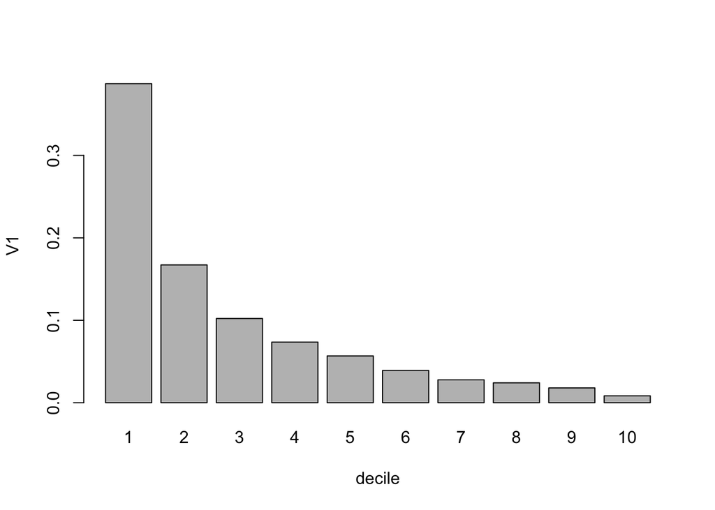

```r
response_rates=bbb[,mean(buyer),by=decile]

barplot(V1~decile,data=response_rates)
```

3. Generate a table showing the number of customers, the number of buyers of “The Art History of Florence,’ and the response rate to the offer by decile for the random sample (i.e. the 50,000 customers) in the dataset.

```r
results <- bbb[, .(num_cust = .N, num_buy = sum(buyer), resp_rate = sum(buyer) / .N), by = decile]

head(results)
```

```
##    decile num_cust num_buy resp_rate
## 1:      8     5000     121    0.0242
## 2:      9     5000      90    0.0180
## 3:      4     5000     368    0.0736
## 4:      6     5000     196    0.0392
## 5:     10     5000      42    0.0084
## 6:      3     5000     511    0.1022
```

4. For the 50,000 customers in the dataset, generate a table showing the average values of the following variables by probability of purchase decile: Total $ spent Months since last purchase, and Number of books purchased for each of the seven categories (i.e., children, youth, cookbooks, do-it-yourself, reference, art and geography).

```r
avg_bbb <- bbb[, .(avg_total = mean(total_), avg_last = mean(last),
                   avg_child = mean(child), avg_youth = mean(youth),
                   avg_cook = mean(cook), avg_do_it = mean(do_it),
                   avg_reference = mean(reference), avg_art = mean(art),
                   avg_geog = mean(geog)),
              by = decile]

avg_bbb
```

```
##     decile avg_total avg_last avg_child avg_youth avg_cook avg_do_it
##  1:      8  191.5660  14.4184    0.8050    0.3604   0.9090    0.4480
##  2:      9  193.6108  17.8576    0.9606    0.4052   1.1182    0.6506
##  3:      4  207.6430   8.7828    0.7526    0.3626   0.7966    0.3404
##  4:      6  199.1302  10.9376    0.7480    0.3648   0.8648    0.3942
##  5:     10  204.3416  25.8684    1.0674    0.4630   1.3094    0.7722
##  6:      3  214.2284   8.6188    0.7910    0.3654   0.7960    0.3698
##  7:      1  257.3526   7.1944    1.0648    0.5138   1.0668    0.4714
##  8:      7  191.3296  12.3724    0.7608    0.3480   0.8362    0.4208
##  9:      5  199.1118   9.5732    0.7580    0.3338   0.8208    0.3698
## 10:      2  224.8692   7.9580    0.8364    0.3928   0.8482    0.3934
##     avg_reference avg_art avg_geog
##  1:        0.2050  0.1140   0.2544
##  2:        0.2524  0.1276   0.3160
##  3:        0.3082  0.3024   0.5404
##  4:        0.2588  0.1634   0.3862
##  5:        0.2476  0.0692   0.2916
##  6:        0.3832  0.4802   0.7010
##  7:        0.5628  1.5006   1.3308
##  8:        0.2274  0.1320   0.2946
##  9:        0.2724  0.2168   0.4638
## 10:        0.4046  0.7530   0.8908
```

5. Summarize and interpret the decile analysis results. Are the patterns in the decile analysis consistent with your conclusions from the logistic regression? (Hint: graph some of the results in the previous question.)

```r
# summarize average values by decile
require(psych)
results2 <- describeBy(bbb,bbb$decile)
results2
```

```
##
##  Descriptive statistics by group
## group: 1
##           vars    n     mean       sd   median  trimmed      mad      min
## acctnum      1 5000 34921.04 14425.91 35123.00 34884.75 18556.22 10009.00
## gender       2 5000     0.58     0.49     1.00     0.60     0.00     0.00
## state*       3 5000     8.63     2.55    10.00     9.00     1.48     1.00
## zip          4 5000 11583.05  5660.24 11204.50 11627.76  5840.70   802.00
## zip3         5 5000   115.44    56.64   112.00   115.88    57.82     8.00
## first        6 5000    32.12    20.48    31.00    31.07    23.72     1.00
## last         7 5000     7.19     5.41     7.00     6.64     5.93     1.00
## book_        8 5000    78.45    42.76    82.00    78.50    60.79    15.00
## nonbook_     9 5000   178.90    86.78   184.00   180.55   108.23     1.00
## total_      10 5000   257.35   100.51   259.00   258.22   108.23    16.00
## purch       11 5000     6.51     3.78     7.00     6.51     5.93     1.00
## child       12 5000     1.06     1.20     1.00     0.88     1.48     0.00
## youth       13 5000     0.51     0.77     0.00     0.36     0.00     0.00
## cook        14 5000     1.07     1.19     1.00     0.89     1.48     0.00
## do_it       15 5000     0.47     0.74     0.00     0.31     0.00     0.00
## reference   16 5000     0.56     0.80     0.00     0.41     0.00     0.00
## art         17 5000     1.50     0.93     1.00     1.47     1.48     0.00
## geog        18 5000     1.33     1.25     1.00     1.19     1.48     0.00
## buyer       19 5000     0.39     0.49     0.00     0.36     0.00     0.00
## prob        20 5000     0.39     0.17     0.33     0.36     0.13     0.22
## decile*     21 5000     1.00     0.00     1.00     1.00     0.00     1.00
## bucket*     22 5000     1.00     0.00     1.00     1.00     0.00     1.00
##                max    range  skew kurtosis     se
## acctnum   60000.00 49991.00  0.01    -1.22 204.01
## gender        1.00     1.00 -0.33    -1.89   0.01
## state*       15.00    14.00 -1.17     0.47   0.04
## zip       21239.00 20437.00  0.14    -0.91  80.05
## zip3        212.00   204.00  0.14    -0.91   0.80
## first        99.00    98.00  0.35    -0.69   0.29
## last         35.00    34.00  1.08     1.90   0.08
## book_       158.00   143.00 -0.04    -1.38   0.60
## nonbook_    341.00   340.00 -0.14    -1.12   1.23
## total_      479.00   463.00 -0.07    -0.66   1.42
## purch        12.00    11.00 -0.05    -1.41   0.05
## child         7.00     7.00  1.10     0.75   0.02
## youth         5.00     5.00  1.57     2.59   0.01
```

[output cut: 426 more lines]

```
## book_       130.00  0.90    -0.64   0.54
## nonbook_    351.00  0.12    -1.07   1.24
## total_      464.00  0.20    -0.64   1.44
## purch        11.00  0.85    -0.77   0.05
## child         7.00  1.38     1.69   0.02
## youth         5.00  1.81     3.64   0.01
## cook          8.00  1.24     1.05   0.02
## do_it         7.00  1.50     2.38   0.01
## reference     4.00  2.29     5.47   0.01
## art           2.00  3.75    13.73   0.00
## geog          4.00  2.11     4.79   0.01
## buyer         1.00 10.77   114.01   0.00
## prob          0.01 -0.08    -1.02   0.00
## decile*       0.00   NaN      NaN   0.00
## bucket*       0.00   NaN      NaN   0.00
```

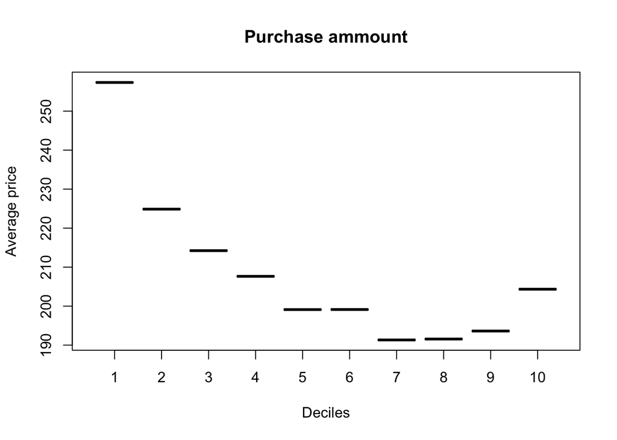

```r
plot(avg_bbb$decile,avg_bbb$avg_total,main = "Purchase ammount",xlab = "Deciles",ylab = "Average price")
```

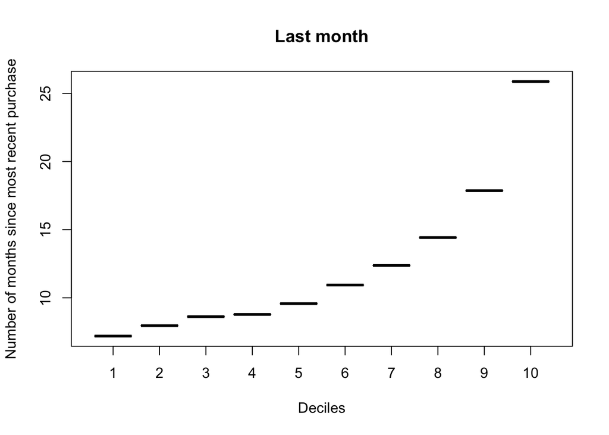

```r
plot(avg_bbb$decile,avg_bbb$avg_last,main = "Last month",xlab = "Deciles",ylab = "Number of months since most recent purchase")
```

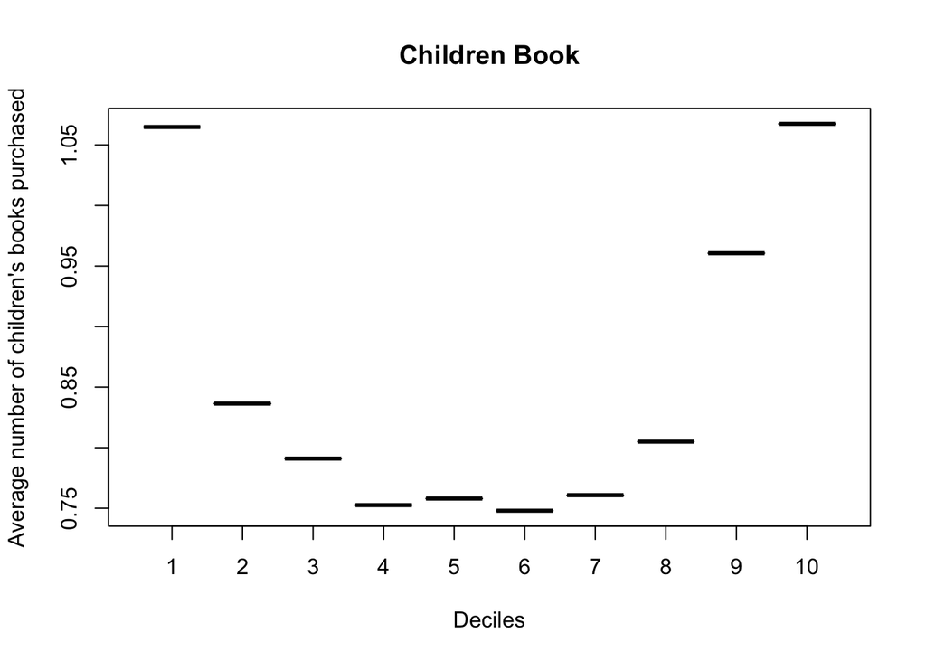

```r
plot(avg_bbb$decile,avg_bbb$avg_child,main = "Children Book",xlab = "Deciles",ylab = "Average number of children's books purchased")
```

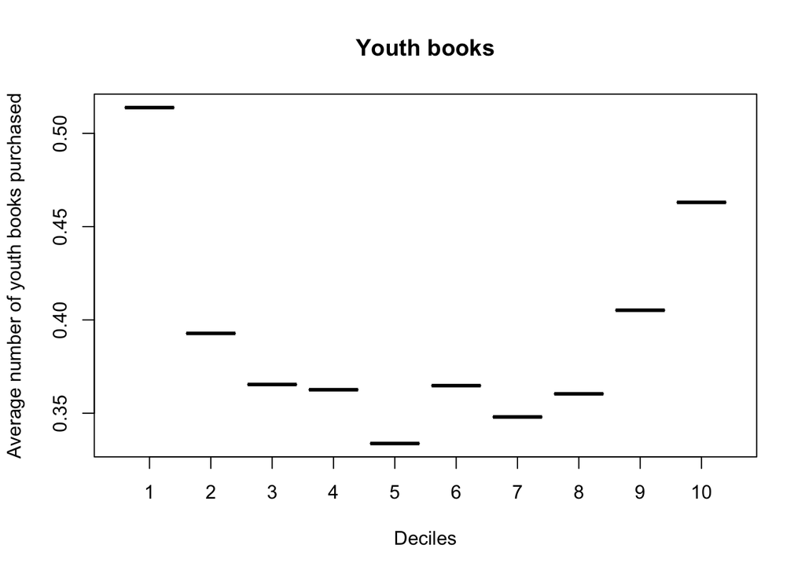

```r
plot(avg_bbb$decile,avg_bbb$avg_youth,main = "Youth books",xlab = "Deciles",ylab = "Average number of youth books purchased")
```

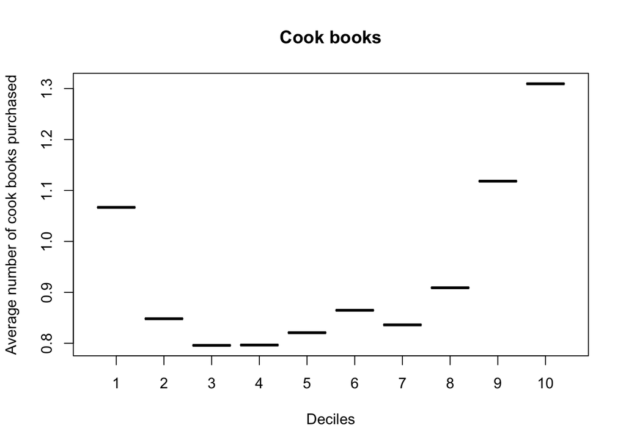

```r
plot(avg_bbb$decile,avg_bbb$avg_cook,main = "Cook books",xlab = "Deciles",ylab = "Average number of cook books purchased")
```

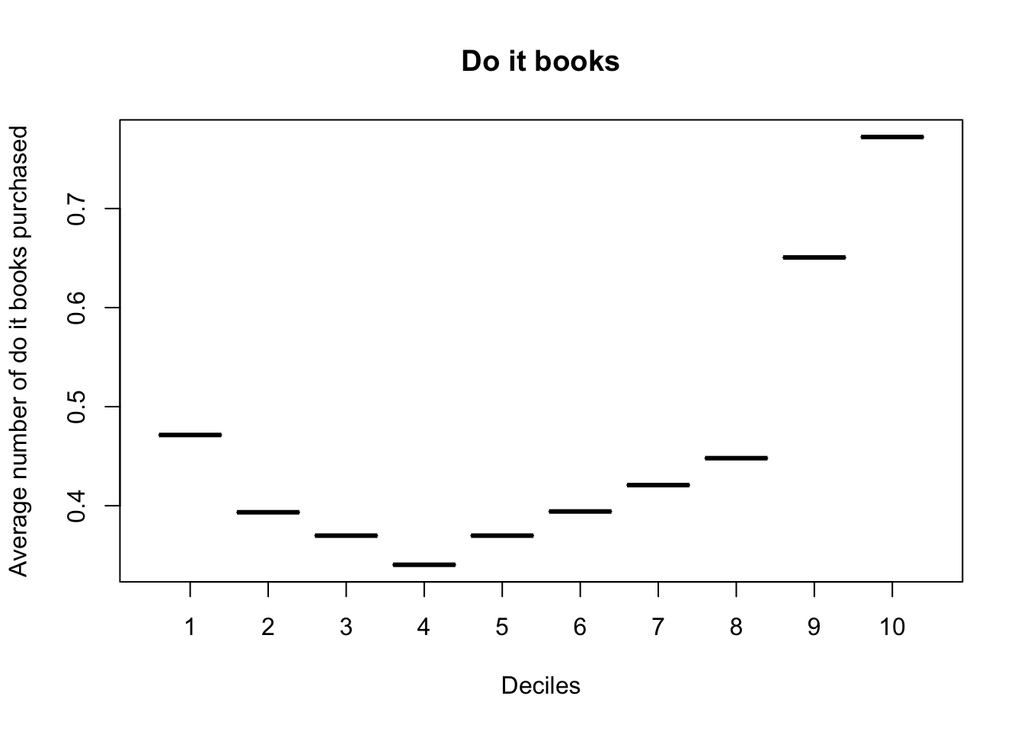

```r
plot(avg_bbb$decile,avg_bbb$avg_do_it,main = "Do it books",xlab = "Deciles",ylab = "Average number of do it books purchased")
```

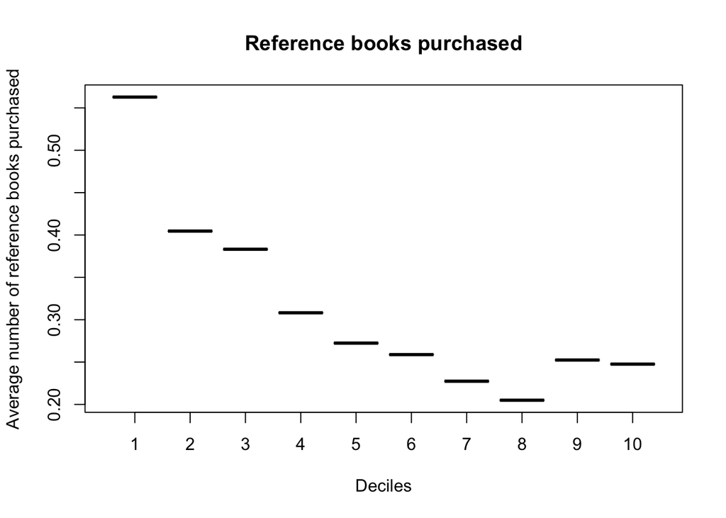

```r
plot(avg_bbb$decile,avg_bbb$avg_reference,main = "Reference books purchased",xlab = "Deciles",ylab = "Average number of reference books purchased")
```

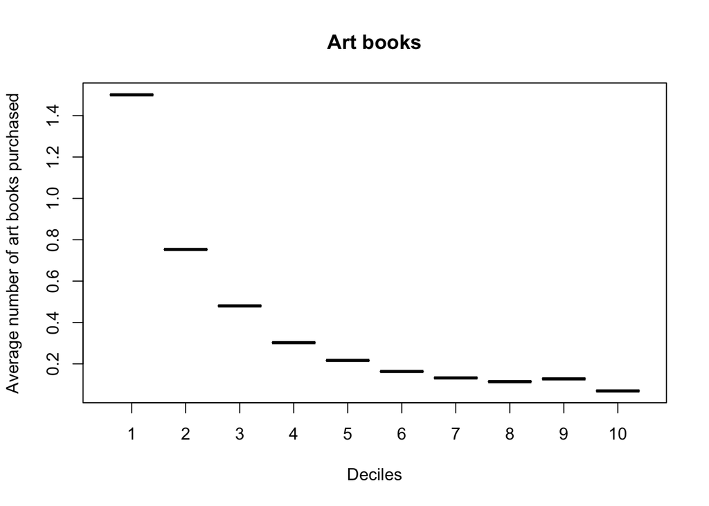

```r
plot(avg_bbb$decile,avg_bbb$avg_art,main = "Art books",xlab = "Deciles",ylab = "Average number of art books purchased")
```

Total: We can see that Top deciles purchase the most in terms of purchase amount and it decreases as the decile progress. Note that there is small rise in Decile 10 but that could be due to population bias.

Children category: We see that its evenly distributed around decile 5, where customers are more likely to buy the book when they are closer to decile 1 or 10.

Youth category: We see that its almost evenly distributed around decile 5 but it peaks at Decile 1.

Cook category: We see that its evenly distributed around decile 5, where customers are more likely to buy the book when they are closer to decile 10.

Do it category: We can see that do it books are most purchased by Decile 10 and the probability of do it books being bought dips at decile 4.

Reference category: We can see that do it books are most purchased by Decile 1 and the probability of do it books being bought dips at decile 8.

Art books: People who buy the book have a higher probability of buying other art books.

Part III: Profitability Analysis Use the following cost information to assess the profitability of using logistic regression to determine which of the remaining 500,000 customers should receive a specific offer: Cost to mail offer to customer: 0.5$ Selling price (shipping included): 18$ Wholesale price paid by BookBinders: 9$ Shipping costs: 3$ 1. What is the breakeven response rate?

The breakeven response rate can be calculated as follows: Revenue per customer = Selling price - Wholesale price - Shipping costs = $18.00 - $9.00 - $3.00 = $6.00 Breakeven cost per response = Cost to mail offer to customer / Revenue per customer = $0.50 / $6.00 = **0.0833** Therefore, the breakeven response rate is 8.33% (i.e., we need at least 8.33% of the targeted customers to respond to the offer to break even).

2. For the customers in the dataset, create a new variable (call it “mailto_logit”) with a value of 1 if the customer’s predicted probability is greater than or equal to the breakeven response rate and 0 otherwise. Hint: You can use data.table’s conditional assignment syntax

```r
cost_mail <- 0.5
selling = 18
whole <-  9
shipping <- 3

total_cost <-  cost_mail+whole+shipping
profit <- selling - total_cost
```

```r
# calculate breakeven response rate
revenue_per_customer <- 18 - 9 - 3
breakeven_cost_per_response <- 0.5 / revenue_per_customer
breakeven_response_rate <- breakeven_cost_per_response * 100
breakeven_response_rate
```

```
## [1] 8.333333
```

```r
# create new variable "mailto_logit"
bbb[, mailto_logit := ifelse(prob >= breakeven_cost_per_response, 1, 0)]
bbb
```

```
##        acctnum gender state   zip zip3 first last book_ nonbook_ total_ purch
##     1:   10001      1    NY 10605  106    49   29   109      248    357    10
##     2:   10002      1    NY 10960  109    39   27    35      103    138     3
##     3:   10003      0    PA 19146  191    19   15    25      147    172     2
##     4:   10004      0    NJ  7016   70     7    7    15      257    272     1
##     5:   10005      0    NY 10804  108    15   15    15      134    149     1
##    ---
## 49996:   59996      0    NY 11967  119     9    9    15       12     27     1
## 49997:   59997      0    NJ  8882   88    25    5    79      294    373     7
## 49998:   59998      1    NJ  7410   74     3    3    15      178    193     1
## 49999:   59999      1    NJ  7090   70    49   29    98      246    344     8
## 50000:   60000      1    NY 11355  113    29    1    60      125    185     5
##        child youth cook do_it reference art geog buyer       prob decile
##     1:     3     2    2     0         1   0    2     0 0.02002900      8
##     2:     0     1    0     1         0   0    1     0 0.01660684      9
```

[output cut: 21 more lines]

3. Out of the 50,000 test sample, how many customers should have received the targeting promotion mail for “The Art History of Florence” based on the breakeven response rate (i.e., the number of mailto_logit ==1 in the data)? Also, among those who would have targeted, what would have been the response rate (i.e., mean of buyer among mailto_logit ==1)? How much higher is this response rate relative to the overall response rate in the data?

```r
# calculate number of customers to receive offer
num_customers <- sum(bbb$mailto_logit)
num_customers
```

```
## [1] 15560
```

```r
# calculate response rate among those who receive offer
response_rate <- mean(bbb$buyer[bbb$mailto_logit == 1])
response_rate
```

```
## [1] 0.2135604
```

```r
# calculate expected profit from campaign
expected_profit <- num_customers * (18 - 9 - 3 - 0.5)
expected_profit
```

```
## [1] 85580
```

4. Consider that there are 500,000 remaining customers for the roll-out (excluding 50,000 test group in the current data. Assuming our test group is similar to the roll-out group (i.e., our test group is representative of the roll-out group), what is the expected number of buyers of ‘The Art History of Florence’ if we do targeted mailing based on the breakeven response rate? Hint: Count the number of buyers among the targeted (mailto_logit==1) in the test group and multiply it by 10 since the roll-out sample is 10 times larger. Alternatively, you can use the response rate.

```r
# calculate expected number of buyers in roll-out group
expected_num_buyers <- num_customers * (mean(bbb$buyer[bbb$mailto_logit == 1]) / mean(bbb$mailto_logit))
expected_num_buyers_rollout <- expected_num_buyers * 10
expected_num_buyers_rollout
```

```
## [1] 106780.2
```